# SAD - sprawozdanie 1

Łukasz Pietraszek, Marcel Kawski

30.11.2021

# Zadanie 1.

### a)

#### i.

Wybrane przez nas stacje to: **Marianowo II**, **Niedzica**, **Ceber**.

```r
cities = c('MARIANOWO II', 'NIEDZICA', 'CEBER')

data <- read.csv('/media/dell/Seagate/Studia/mgr/1_sem/SAD/projekty/projekt1/descriptive-statistics/data/2021_07_k/k_d_07_2021.csv',
                 fill = TRUE, header = FALSE)

colnames(data) <- c('kod_stacji', 'nazwa_stacji', 'rok', 'miesiąc', 'dzień',
                    'maks_temp', 'stat_pom_tmax', 'min_temp', 'stat_pom_tmin',
                    'sr_temp', 'stat_pom_std', 'temp_min_gr', 'stat_pom_tmng',
                    'suma_opad', 'stat_pom_smdb', 'rodz_opad', 'wys_pokr_sn',
                    'stat_pom_pksn')

data1 <- data[data[, 'nazwa_stacji'] == cities[1],]
data2 <- data[data[, 'nazwa_stacji'] == cities[2],]
data3 <- data[data[, 'nazwa_stacji'] == cities[3],]
```

Wykresy pudełkowe maksymalnych dobowych temperatur dla wybranych miast:

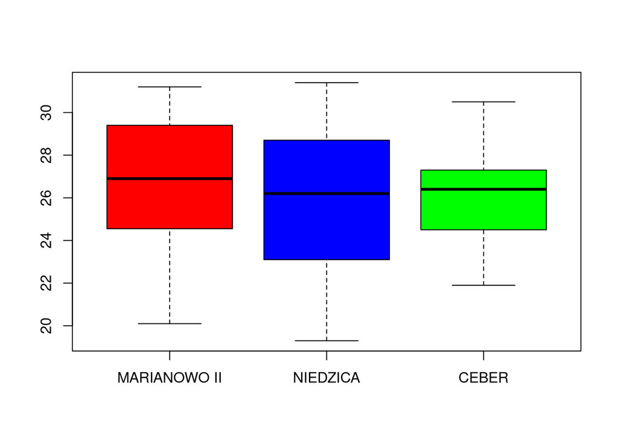

```r
colors = c('red', 'blue', 'green')

boxplot(data1[, 'maks_temp'], data2[, 'maks_temp'], data3[, 'maks_temp'],
        names = cities, col = colors)
```

Mediany maksymalnych dobowych temperatur dla wybranych miast:

```r
median1 <- median(data1[, 'maks_temp'])
median2 <- median(data2[, 'maks_temp'])
median3 <- median(data3[, 'maks_temp'])

cat(cities[1], ':', median1, '\n')
```

```
## MARIANOWO II : 26.9
```

```r
cat(cities[2], ':', median2, '\n')
```

```
## NIEDZICA : 26.2
```

```r
cat(cities[3], ':', median3, '\n')
```

```
## CEBER : 26.4
```

**Komentarz:** Najwyższą medianę maksymalnej dobowej temperatury ma miasto Marianowo II. Zgadza się to z danymi zaprezentowanymi na wykresie pudełkowym.

Średnie arytmetyczne maksymalnych dobowych temperatur dla wybranych miast:

```r
mean1 <- mean(data1[, 'maks_temp'])
mean2 <- mean(data2[, 'maks_temp'])
mean3 <- mean(data3[, 'maks_temp'])

cat(cities[1], ':', mean1, '\n')
```

```
## MARIANOWO II : 26.95806
```

```r
cat(cities[2], ':', mean2, '\n')
```

```
## NIEDZICA : 25.68065
```

```r
cat(cities[3], ':', mean3, '\n')
```

```
## CEBER : 26.06452
```

**Komentarz:** Najwyższą średnią arytmetyczną maksymalnej dobowej temperatury ma miasto Marianowo II.

Porównanie statystyk:

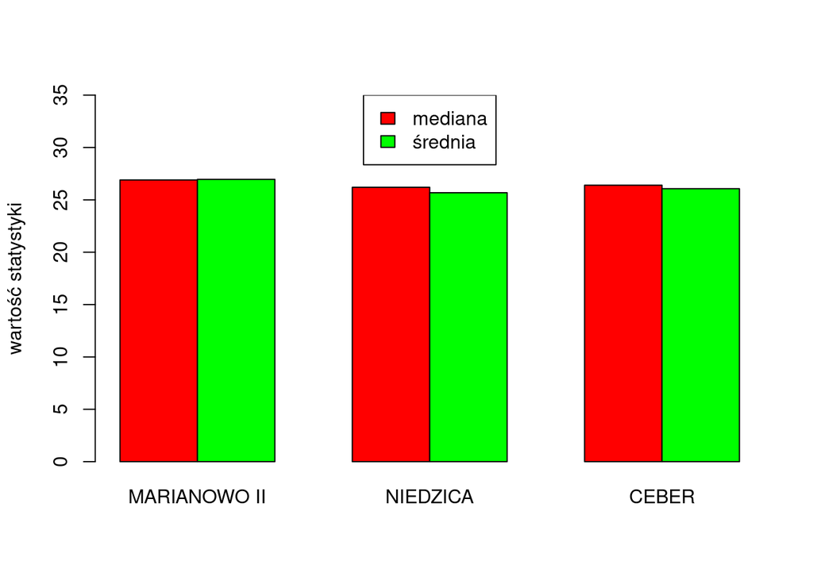

```r
medians <- c(median1, median2, median3)
means <- c(mean1, mean2, mean3)
stats <- rbind(medians, means)

barplot(stats, names = cities, ylim = c(0, 35), ylab = 'wartość statystyki',
        col = c("red","green"), beside=TRUE)
legend('top', c('mediana', 'średnia'), fill = c("red","green"))
```

**Komentarz:** Wykres ten nie obrazuje dobrze różnic w statystykach. Najbardziej przydatnym wykresem okazuje się wykres pudełkowy.

Odchylenia standardowe maksymalnych dobowych temperatur dla wybranych miast:

```r
sd1 <- sd(data1[, 'maks_temp'])
sd2 <- sd(data2[, 'maks_temp'])
sd3 <- sd(data3[, 'maks_temp'])

cat(cities[1], ':', sd1, '\n')
```

```
## MARIANOWO II : 2.872255
```

```r
cat(cities[2], ':', sd2, '\n')
```

```
## NIEDZICA : 3.473175
```

```r
cat(cities[3], ':', sd3, '\n')
```

```
## CEBER : 2.341872
```

Porównanie odchyleń standardowych:

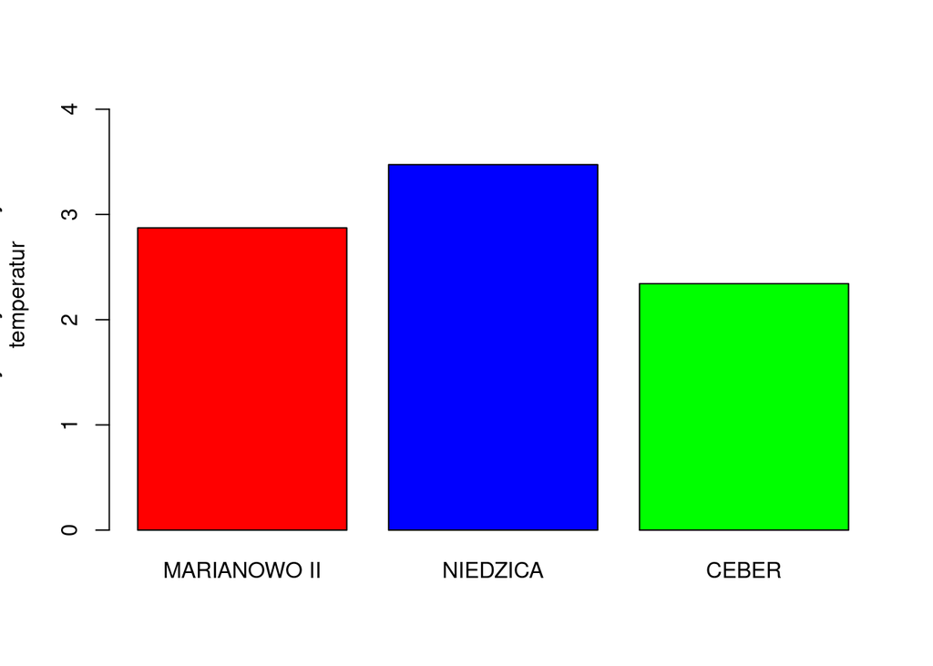

```r
sds <- c(sd1, sd2, sd3)
barplot(sds, names = cities, ylim = c(0, 4), ylab = 'std maksymalnych dobowych
        temperatur', col = colors)
```

#### ii.

Dobowe amplitudy temperatur:

```r
ampl1 = data1[, 'maks_temp'] - data1[, 'min_temp']
ampl2 = data2[, 'maks_temp'] - data2[, 'min_temp']
ampl3 = data3[, 'maks_temp'] - data3[, 'min_temp']
```

Wykresy pudełkowe dobowych amplitud temperatur:

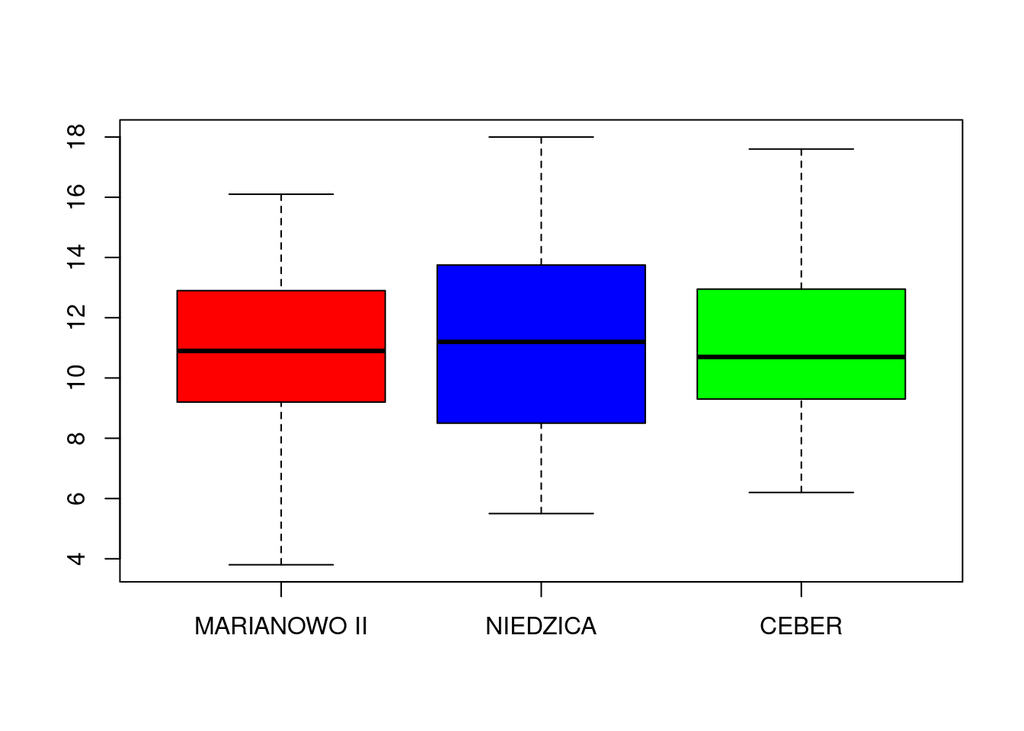

```r
boxplot(ampl1, ampl2, ampl3, names = cities, col = c('red', 'blue', 'green'))
```

Mediany dobowych amplitud temperatur dla wybranych miast:

```r
median1 <- median(ampl1)
median2 <- median(ampl2)
median3 <- median(ampl3)

cat(cities[1], ':', median1, '\n')
```

```
## MARIANOWO II : 10.9
```

```r
cat(cities[2], ':', median2, '\n')
```

```
## NIEDZICA : 11.2
```

```r
cat(cities[3], ':', median3, '\n')
```

```
## CEBER : 10.7
```

Średnie dobowych amplitud temperatur dla wybranych miast:

```r
mean1 <- mean(ampl1)
mean2 <- mean(ampl2)
mean3 <- mean(ampl3)

cat(cities[1], ':', mean1, '\n')
```

```
## MARIANOWO II : 10.92258
```

```r
cat(cities[2], ':', mean2, '\n')
```

```
## NIEDZICA : 11.33548
```

```r
cat(cities[3], ':', mean3, '\n')
```

```
## CEBER : 11.1129
```

Odchylenia standardowe dobowych amplitud temperatur dla wybranych miast:

```r
sd1 <- sd(ampl1)
sd2 <- sd(ampl2)
sd3 <- sd(ampl3)

cat(cities[1], ':', sd1, '\n')
```

```
## MARIANOWO II : 2.695145
```

```r
cat(cities[2], ':', sd2, '\n')
```

```
## NIEDZICA : 3.607173
```

```r
cat(cities[3], ':', sd3, '\n')
```

```
## CEBER : 2.827572
```